# Business Data Analytics. Practice Session

Customer Lifecycle Management

Business relationships with the customers are not **static** – they change over time. It is crucial for the company to understand these dynamic processes. The customer relationship management (CRM) is a huge area that encompasses multiple practices, directions, and approaches related to customer interactions with the business. One of the central directions is **the Customer Lifecycle Value (CLV)**, which is the topic of this session. The first approach that we will study is based on **heuristics**, where we do not use any automatic methods, but a fairly simple analysis in order to calculate **Customer Lifetime Value (CLV)**. Then, we will learn how to use **simple and multiple linear regressions** in the context of CRM. We will follow machine learning practices discussed during the lecture.

Let’s install & load the required packages:

```r
install.packages("tidyverse")
install.packages("data.table")
```

```r
library("tidyverse")
library("data.table")
```

and the dataset:

```r
dt_raw <- read.csv(file.choose()) # clv_transactions.csv
head(dt_raw, 3)
```

```
##   transaction_id transaction_date customer_id amount
## 1              1       2012-09-04           1  20.96
## 2              2       2012-05-15           2  10.87
## 3              3       2014-05-23           2   2.21
```

- transaction_id - unique ID of some transaction;
- transaction_date - date when transaction was executed;
- customer_id - unique ID of the customer;
- amount - total amount of money the were transfered.

## Customer Lifecycle Value

Our goal here is to calculate CLV, which is the cash flow attributed to the customer during the entire relationship with the company. CLV is a metric that can be used for many different purposes:

- estimation of the customer value in order to target the most valuable ones
- reference for the markieting campaigns: how much to spend or whether to spend?
- and monitoring the impact of such campaigns
- measurement of customer loyalty
- optimization of resource allocation
- etc..

There are many methodologies of CLV, which can be very complex and include all the details taking into account all the spendings. More generally, CLV can be divided into two broad categoris: historical CLV and predictive CLV. Let us take the simple approach and calculate the historical value.

```r
summary(dt_raw)
```

[output not shown]

```r
customers_stat <- dt_raw %>%
  group_by(customer_id) %>% # group intial dataset by customers
  summarise(transaction_per_customer = n(), # calculates total number of transactions for each customer
            amount_per_customer = sum(amount), # adds up all amounts for each customer
            amount_per_transaction = amount_per_customer/transaction_per_customer)
# calculate statistics on the customers

summarise_all(customers_stat[,-1], mean) # calculate averages (wrt customer)
```

```
## # A tibble: 1 x 3
##   transaction_per_customer amount_per_customer amount_per_transaction
##                      <dbl>               <dbl>                  <dbl>
## 1                     4.18                33.7                   7.95
```

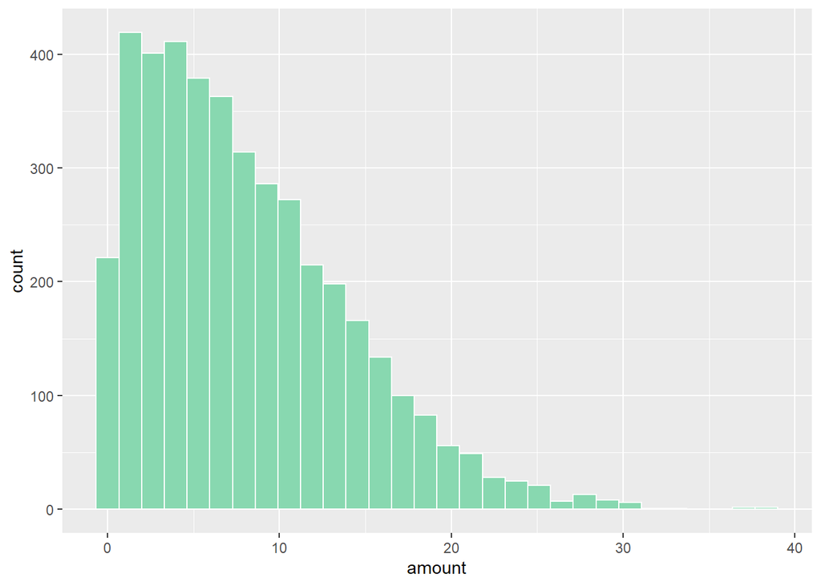

```r
ggplot(dt_raw, aes(x=amount)) +
  geom_histogram(fill='#88d8b0', color='white') # histogram of transactional amounts
```

Let’s keep the raw dataset unchanged and create a new dataset, where we start to collect required features:

```r
customers <- dt_raw %>%
  group_by(customer_id) %>%
  mutate(year = as.integer(substr(transaction_date, start=1, stop=4))) %>% # we take only year
  mutate(min_year = as.integer(min(year)),
         max_year=as.integer(max(year)),
         years_active=as.integer((max_year-min_year)+1)) # years of first and last purchase of the customer and amount of years he/she was active
customers
```

```
## # A tibble: 4,181 x 8
## # Groups:   customer_id [1,000]
##    transaction_id transaction_date customer_id amount  year min_year max_year
##             <int> <fct>                  <int>  <dbl> <int>    <int>    <int>
##  1              1 2012-09-04                 1  21.0   2012     2012     2012
##  2              2 2012-05-15                 2  10.9   2012     2012     2014
##  3              3 2014-05-23                 2   2.21  2014     2012     2014
##  4              4 2014-10-24                 2  10.5   2014     2012     2014
##  5              5 2012-10-13                 2   3.94  2012     2012     2014
##  6              6 2013-01-23                 2  12.4   2013     2012     2014
##  7              7 2014-03-09                 2   1.59  2014     2012     2014
##  8              8 2013-11-17                 2   2.75  2013     2012     2014
##  9              9 2014-10-10                 2   3.51  2014     2012     2014
## 10             10 2012-11-26                 3  21.6   2012     2012     2015
## # ... with 4,171 more rows, and 1 more variable: years_active <int>
```

### set.seed

When using this random number generating feature in R programming, the set seed command enables the user to set constraints for generating random numbers for a statistical test. The set seed command is assigned an index whereby the generated sequence of numbers is stored.

Let’s check the timespan of a few customers to understand the data better:

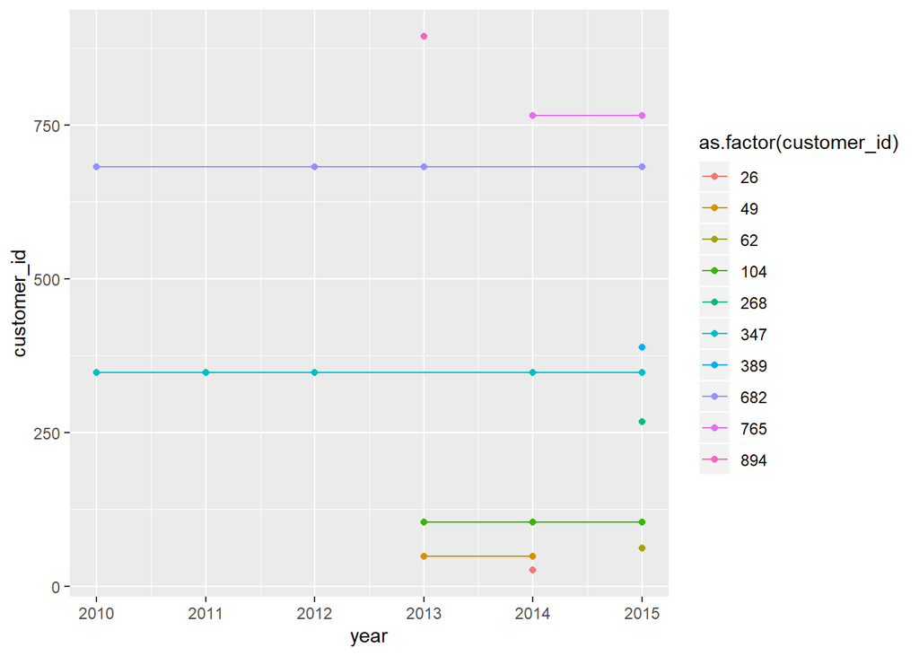

```r
set.seed(888) # put any number for reproducibility of pseudorandom generator
customers_sample <- sample(unique(customers$customer_id), size = 10, replace = F) # take IDs of 10 random customers

filter(customers, customer_id %in% customers_sample) %>% # we pick only rows where customer id is the one we sampled (operator %in% will take all the rows where the customer id matches)
  ggplot(aes(x=year, y=customer_id, color=as.factor(customer_id))) +
  geom_line() + geom_point() # y axis is not important, we just want to follow customers in time
```

We can note several important things. Namely, the customers are heterogeneous – they spend at different years, and also do not purchase every single year. Now, here we have to make a decision how to define **active customers**. One definition would be to consider in our calculations any customer who kept purchasing (even if in this year he did not purchase anything). Or take into account (per year basis) only a set of customers who were purchasing in the considered year. We will adopt the second approach as it will be more tricky to calculate:

```r
active_customers <- customers %>%
  ungroup() %>% # removing existing groups
  group_by(min_year, year) %>% # group customers by the starting year and the transactional years.
  # here we forget about customer ID and start to calculate yearly numbers
  summarise(customers_unique=length(unique(customer_id)),  # number of unique customers for the pairs (starting year, transactional year)
            transactions_unique=length(unique(transaction_id)), # number of unique transactions
            amount = sum(amount)) %>% # amount of money spent
  mutate(cumulative_amount=cumsum(amount)) #cumulative amount of money spent
head(active_customers,3)
```

```
## # A tibble: 3 x 6
## # Groups:   min_year [1]
##   min_year  year customers_unique transactions_unique amount cumulative_amount
##      <int> <int>            <int>               <int>  <dbl>             <dbl>
## 1     2010  2010              172                 260  2255.             2255.
## 2     2010  2011               93                 177  1359.             3614.
## 3     2010  2012              104                 195  1658.             5272.
```

```r
active_customers_table <- active_customers %>% # for nice matrix format
  select(min_year, year, customers_unique) %>% # you can pick any feature to display in the matrix
  spread(key=year, value=customers_unique)
active_customers_table
```

```
## # A tibble: 6 x 7
## # Groups:   min_year [6]
##   min_year `2010` `2011` `2012` `2013` `2014` `2015`
##      <int>  <int>  <int>  <int>  <int>  <int>  <int>
## 1     2010    172     93    104     91    103     82
## 2     2011     NA    170     92     98     89     88
## 3     2012     NA     NA    163    109     98     90
## 4     2013     NA     NA     NA    180    103    102
## 5     2014     NA     NA     NA     NA    155     90
## 6     2015     NA     NA     NA     NA     NA    160
```

The second part is to calculate for each year the number of **new customers**:

```r
new_customers <- customers %>% # we have a different grouping, so it is easier to start new table
  ungroup() %>%
  group_by(min_year) %>% # grouping only by starting year
  summarise(new_customers=length(unique(customer_id))) # how many unique customers where each starting year?
head(new_customers,3)
```

```
## # A tibble: 3 x 2
##   min_year new_customers
##      <int>         <int>
## 1     2010           172
## 2     2011           170
## 3     2012           163
```

Combine the two datasets:

```r
active_customers <- left_join(active_customers, new_customers, by='min_year') # adding new_customers column to active_customers
head(active_customers, 3)
```

```
## # A tibble: 3 x 7
## # Groups:   min_year [1]
##   min_year  year customers_unique transactions_un~ amount cumulative_amou~
##      <int> <int>            <int>            <int>  <dbl>            <dbl>
## 1     2010  2010              172              260  2255.            2255.
## 2     2010  2011               93              177  1359.            3614.
## 3     2010  2012              104              195  1658.            5272.
## # ... with 1 more variable: new_customers <int>
```

Now, we are ready to calculate several important measures:

1. $\text{customer retention rate} = \text{active customers}/ \text{new customers}$
2. $\text{transactions per customer} = \text{transactions}/ \text{active customers}$
3. $\text{amount per transaction} = \text{amount}/\text{transactions}$

```r
active_customers_stat <- active_customers %>%
  mutate(retention = customers_unique/new_customers) %>%
  mutate(transaction_per_customer = transactions_unique/customers_unique) %>%
  mutate(amount_per_transaction = amount/transactions_unique)
```

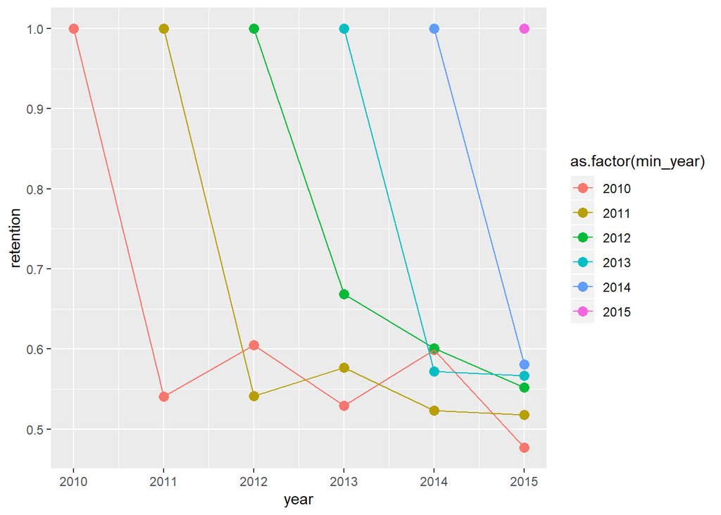

```r
active_customers_stat %>%
  ungroup() %>%
  ggplot(aes(y=retention, x=year,
            group=min_year, color=as.factor(min_year))) +
  geom_point(size=3) + geom_line()
```

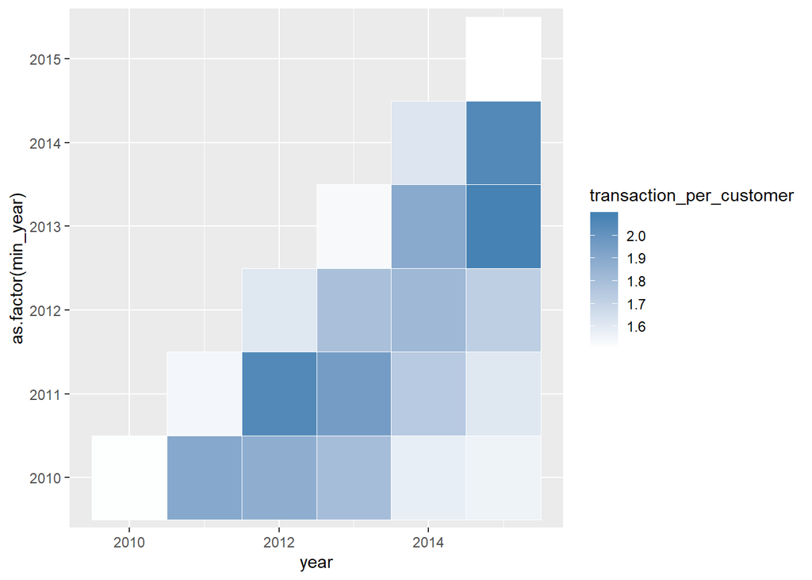

```r
active_customers_stat %>%
  ungroup() %>%
  ggplot(aes(y=as.factor(min_year), x=year)) + geom_tile(aes(fill=transaction_per_customer), colour='white') +
  scale_fill_gradient(low = "white", high = "steelblue")
```

Looking long enough at these numbers :), we can infer:

1. we are able to retain around 60% of the new customers for the next year
2. the transactions per customer are somewhat higher than for the first year - it is in our interest to keep customers

Now we can also calculate the historical CLV, which is cumulative spending per customer over time divided by amount of new customers each year

```r
active_customers_stat <- active_customers %>%
  mutate(historicCLV = cumulative_amount/new_customers)

historicCLV <- active_customers_stat %>%
  select(contains('year'), historicCLV) %>%
  spread(key=year, value=historicCLV)
historicCLV
```

```
## # A tibble: 6 x 7
## # Groups:   min_year [6]
##   min_year `2010` `2011` `2012` `2013` `2014` `2015`
##      <int>  <dbl>  <dbl>  <dbl>  <dbl>  <dbl>  <dbl>
## 1     2010   13.1   21.0   30.7   38.5   46.1   52.1
## 2     2011   NA     13.2   22.1   32.1   39.4   46.2
## 3     2012   NA     NA     13.4   23.8   32.1   39.9
## 4     2013   NA     NA     NA     12.1   20.1   29.1
## 5     2014   NA     NA     NA     NA     11.8   21.1
## 6     2015   NA     NA     NA     NA     NA     12.0
```

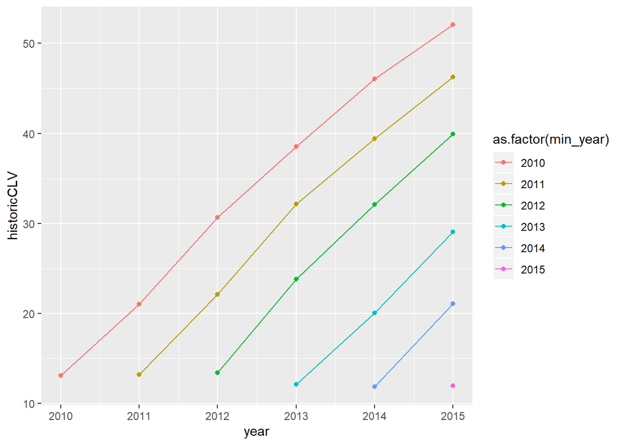

```r
active_customers_stat %>%
  ungroup() %>%
  ggplot(aes(x=year, y=historicCLV, color=as.factor(min_year))) +
  geom_point() + geom_line()
```

If we want to know just the age of customers in months (e.g we want customers who are 12 months old considered the same instead of separate cohorts), we need to bring it to common scale:

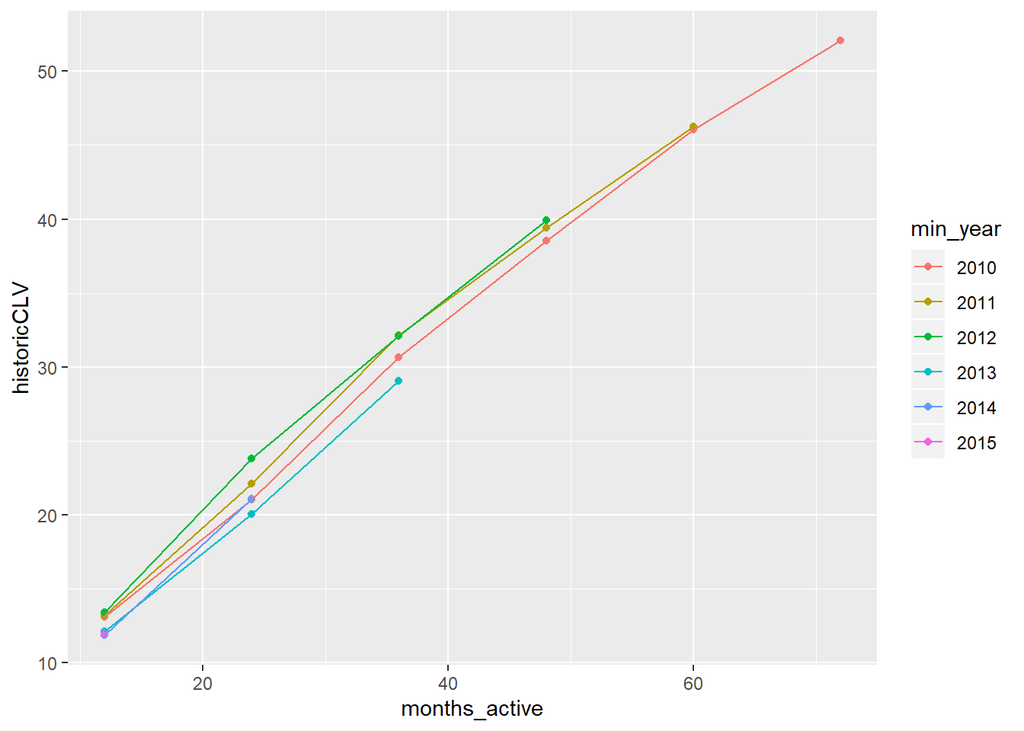

```r
active_customers_stat <- active_customers_stat  %>%
  ungroup() %>%
  mutate(months_active = ((year-min_year)+1)*12) %>% # instead of years we calculate months till start
  mutate(min_year = as.factor(min_year))

ggplot(active_customers_stat, aes(x=months_active, y=historicCLV, color=min_year)) +
  geom_point() + geom_line()
```

```r
weighted_historic_CLV <- active_customers_stat %>%
  mutate(vol=(historicCLV*customers_unique)) %>%
  group_by(months_active) %>%
  summarise(res=sum(vol)/sum(customers_unique))
weighted_historic_CLV
```

```
## # A tibble: 6 x 2
##   months_active   res
##           <dbl> <dbl>
## 1            12  12.6
## 2            24  21.6
## 3            36  31.0
## 4            48  39.3
## 5            60  46.1
## 6            72  52.1
```

Let’s create a plot with the estimated averages of historical CLV. Also, we want to save it for further use:

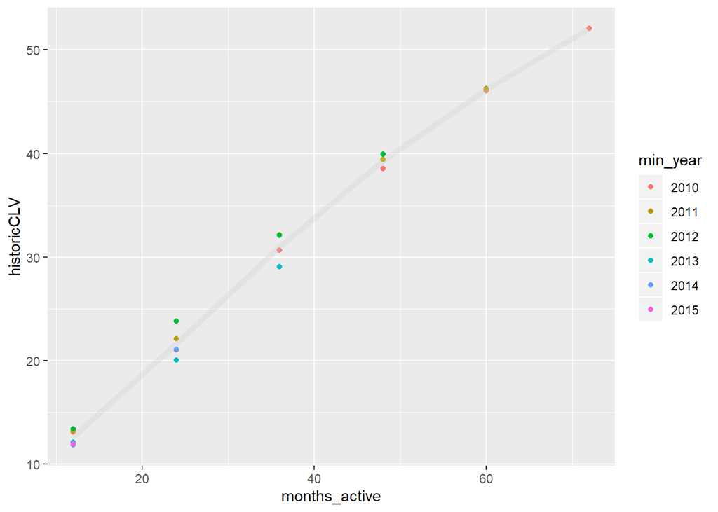

```r
plot1 <- ggplot() +
  geom_point(data=active_customers_stat, aes(x=months_active, y=historicCLV, color=min_year)) +
  geom_line(data=weighted_historic_CLV, aes(x=months_active, y=res), color='grey80', size=2, alpha=0.3)
plot1
```

## Simple Linear regression

What if we want to extrapolate the curve? To predict the current values (**to fit the model**), and use this model for future values?

```r
# simple regression
start <- Sys.time()
m1 <- lm(res~months_active, data=weighted_historic_CLV) # the formula format is y~x or y~x1+x2
lm1_time <- Sys.time() - start
summary(m1) # details of the models
```

```
##
## Call:
## lm(formula = res ~ months_active, data = weighted_historic_CLV)
##
## Residuals:
##       1       2       3       4       5       6
## -1.2421 -0.1746  1.1636  1.5106  0.3965 -1.6541
##
## Coefficients:
##               Estimate Std. Error t value Pr(>|t|)
## (Intercept)    5.87048    1.32498   4.431   0.0114 *
## months_active  0.66468    0.02835  23.444 1.96e-05 ***
## ---
## Signif. codes:  0 '***' 0.001 '**' 0.01 '*' 0.05 '.' 0.1 ' ' 1
##
## Residual standard error: 1.423 on 4 degrees of freedom
## Multiple R-squared:  0.9928, Adjusted R-squared:  0.991
## F-statistic: 549.6 on 1 and 4 DF,  p-value: 1.962e-05
```

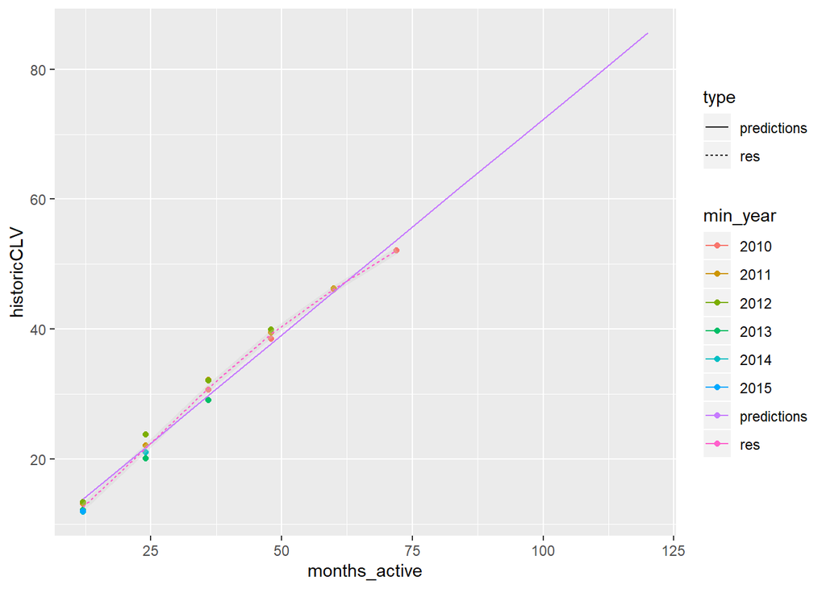

```r
weighted_historic_CLV$predictions <- predict(m1, weighted_historic_CLV) # we want to predict using the fitted model
future_predictions <- data.frame(months_active=c(12*c(7:10)), res=NA, predictions=NA) # let's create future values
future_predictions$predictions <- predict(m1, future_predictions) # make predictions for future values
predictions <- rbind.data.frame(weighted_historic_CLV, future_predictions) # bind them together
predictions <- gather(predictions, type, value, -months_active) # gathering for easier plotting

plot2 <- plot1 + geom_line(data=predictions, aes(x=months_active, y=value, group=type, linetype=type, color=type))
plot2
```

## Multiple linear regression

Now, what if we are more ambitious? Our desire is not just to fit general function, but to predict amount spent for each customer. Can we do that? Depends on the data. Assume that we performed a questionnaire upon the registration, collected some clicks on our website and also have information about proposed discounts for some of the customers:

```r
customer_survey <- read.csv(file.choose()) # customer_transact_survey.csv
head(customer_survey, 3)
```

```
##   customer_id gender age discount_proposed clicks_in_eshop
## 1           1      1  71                 0               1
## 2           2      1  42                 1               3
## 3           3      1  49                 1               3
```

Next step is to think, how to plan our experiment. What we want to predict? We decided to predict for all customers who made transactions in their first year ($t_{0}$), what would be the amount of money spent next year ($t_{1}$). For that reason we will discard:

- all customers who do not have the information about $t_{1}$
- all the information about future years $t_{k}$, where $k>1$

Note that we want to train **generalized model** : we do train the model on customers for whom we know the first and the next year, but we want to apply it on the different customers – those for whom we know only their first year, but don’t know anything about their second year (as it is in the future). For example, we would be able to apply this model using data from 2017 to predict 2018.

```r
#collect features, this one you already seen. the only difference is groupings
dt_year <- dt_raw %>%
  mutate(year = substr(transaction_date, start=1, stop=4), year=as.integer(year)) %>%
  group_by(customer_id) %>%
  mutate(min_year = min(year), max_year=max(year), years_active=max_year-min_year) %>% # creating min, max years
  ungroup() %>%
  group_by(customer_id, year) %>%
  summarise(transaction_per_customer = n(), # amount of reservations in each group
            amount_per_customer = sum(amount),
            amount_per_transaction=amount_per_customer/transaction_per_customer,
            min_year=first(min_year),
            years_active=first(years_active))
dt_year
```

```
## # A tibble: 2,432 x 7
## # Groups:   customer_id [1,000]
##    customer_id  year transaction_per~ amount_per_cust~ amount_per_tran~ min_year
##          <int> <int>            <int>            <dbl>            <dbl>    <int>
##  1           1  2012                1            21.0             21.0      2012
##  2           2  2012                2            14.8              7.40     2012
##  3           2  2013                2            15.1              7.56     2012
##  4           2  2014                4            17.8              4.45     2012
##  5           3  2012                1            21.6             21.6      2012
##  6           3  2013                2            25.4             12.7      2012
##  7           3  2014                2             7.68             3.84     2012
##  8           3  2015                2             7.83             3.92     2012
##  9           4  2015                1             0.54             0.54     2015
## 10           5  2015                2            21.4             10.7      2015
## # ... with 2,422 more rows, and 1 more variable: years_active <int>
```

```r
# filter only those who were more than one year active
dt_prep <- filter(dt_year, years_active!=0) %>%
  mutate(year_number=row_number())  %>% # identify what is the first, second year and so on
  filter(year_number %in% c(1,2)) %>% #let's take only a year old customers next year revenue.
  select(customer_id, transaction_per_customer, amount_per_customer, amount_per_transaction, year_number)
#select features of interest

# as tidyr does not allow to spread several columns, we are using dcast in data.table
dt_feat_table <- dcast(setDT(dt_prep), customer_id ~ year_number, value.var=c('transaction_per_customer', 'amount_per_customer', 'amount_per_transaction'))
# it is like "spread" but several columns can be spread simultaniously

# discard all the features about second year (we could not know them in advance)
# but keep our y - we want to predict next year amount per customer
dt_feat_table <- select(dt_feat_table, -contains("_2"), 'amount_per_customer_2')
```

Let’s join our transactional preprocessed data with our survey:

```r
dt_feat_table <- left_join(dt_feat_table, customer_survey, by='customer_id')
dt_feat_table$gender <- as.factor(dt_feat_table$gender)
dt_feat_table$discount_proposed <- as.factor(dt_feat_table$discount_proposed)
# it is important to translate necessary features
# into factors!
```

Now, we divide our data on two sets: training and test. We want to **train model** on the data, but to **validate the model** we need to use test:

```r
set.seed(385) # fix the seed for reproducibility
train_idx <- sample(nrow(dt_feat_table), round(nrow(dt_feat_table)/100*80,0), replace = F) # usualy data is splited in 20% of test data and 80% of train
train <- dt_feat_table[train_idx,]
test <- dt_feat_table[-train_idx,]
```

Now we can use multiple variables to train our model:

```r
#model_1 <- lm(data=train[,-1], amount_per_customer_2 ~ .)
start <- Sys.time()
model_1 <- lm(data=train[,-1], amount_per_customer_2 ~ amount_per_customer_1 + transaction_per_customer_1 +
                amount_per_transaction_1 + gender + age + discount_proposed + clicks_in_eshop)
lm3_time <- Sys.time() - start
summary(model_1)
```

```
##
## Call:
## lm(formula = amount_per_customer_2 ~ amount_per_customer_1 +
##     transaction_per_customer_1 + amount_per_transaction_1 + gender +
##     age + discount_proposed + clicks_in_eshop, data = train[,
##     -1])
##
## Residuals:
##      Min       1Q   Median       3Q      Max
## -11.3431  -3.0884  -0.2934   2.4622  23.4805
##
## Coefficients:
##                              Estimate Std. Error t value Pr(>|t|)
## (Intercept)                -24.680597   1.627710 -15.163  < 2e-16 ***
## amount_per_customer_1        0.006294   0.055650   0.113   0.9100
## transaction_per_customer_1   0.180761   0.519212   0.348   0.7279
## amount_per_transaction_1     0.025182   0.085411   0.295   0.7682
## gender1                     -0.798680   0.435633  -1.833   0.0673 .
## age                          0.219532   0.029756   7.378 6.44e-13 ***
## discount_proposed1         -34.479706   1.861467 -18.523  < 2e-16 ***
## clicks_in_eshop             23.111674   0.834923  27.681  < 2e-16 ***
## ---
## Signif. codes:  0 '***' 0.001 '**' 0.01 '*' 0.05 '.' 0.1 ' ' 1
##
## Residual standard error: 4.765 on 518 degrees of freedom
## Multiple R-squared:  0.8425, Adjusted R-squared:  0.8404
## F-statistic:   396 on 7 and 518 DF,  p-value: < 2.2e-16
```

```r
test$prediction_linear <- predict(model_1, newdata=test[,-1]) # predictions on a test set

prediction_quality <- function(predictions, real_values){ # I wrote this function to use different measures of accuracy
  diff <- sum((real_values - predictions)^2)
  mse <- diff/length(predictions)
  rmse <- sqrt(mse)
  mae <- sum(abs(real_values - predictions))/length(predictions)
  print(paste("mean squared error is ", mse))
  print(paste("root mean squared error is ", rmse))
  print(paste("mean absolute error is ", mae))
  print(lm3_time)
}
prediction_quality(test$prediction_linear, test$amount_per_customer_2)
```

```
## [1] "mean squared error is  21.9160073301019"
## [1] "root mean squared error is  4.68145354885658"
## [1] "mean absolute error is  3.61740752092865"
## Time difference of 0.003990889 secs
```